# Hito3

# Naive Bayes

```python
from sklearn.naive_bayes import GaussianNB  # naive bayes
clf = GaussianNB()
X_train, X_test, y_train, y_test = train_test_split(X, y, test_size=.30,train_size=0.70, stratify=y)
clf.fit(X_train, y_train)
predictions = clf.predict(X_test)

print("Accuracy:", metrics.accuracy_score(y_test, predictions))
print(metrics.classification_report(y_test, predictions))
```

```
Accuracy: 0.5862
             precision    recall  f1-score   support

        1.0       0.60      0.63      0.61      7898
        3.0       0.57      0.54      0.55      7102

avg / total       0.59      0.59      0.59     15000
```

# Random Forest

```python
from sklearn.ensemble import RandomForestClassifier
clf = RandomForestClassifier(n_estimators=100)
X_train, X_test, y_train, y_test = train_test_split(X, y, test_size=.30,train_size=0.70, stratify=y)
clf.fit(X_train, y_train)
predictions = clf.predict(X_test)

print("Accuracy:", metrics.accuracy_score(y_test, predictions))
print(metrics.classification_report(y_test, predictions))
```

```
Accuracy: 0.6234666666666666
             precision    recall  f1-score   support

        1.0       0.63      0.69      0.66      7898
        3.0       0.61      0.55      0.58      7102

avg / total       0.62      0.62      0.62     15000
```

```
Text(0.5,0,'Predicted label')
```

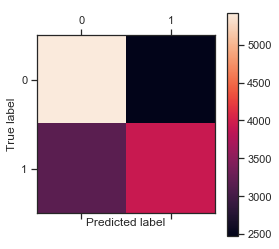

```python
cm = confusion_matrix(y_test, predictions)
plt.matshow(cm)
plt.colorbar()
plt.ylabel('True label')
plt.xlabel('Predicted label')
```

Nuestro clasificador no tuvo buenos resultados bajo ningún método solo mejoró un 1% (60% aprox) el rendimiento con respecto al hito 2, por lo que se intentó otra técnica de Minería de Datos.

# Reglas de asociación

Se buscaron reglas de asociación en el dataset, para así obtener diferencias entre los alumnos que terminaron a tiempo y los que no. Primero se categorizaron las columnas a utilizar y luego se dividió el dataset entre los que terminaron a tiempo y los que no, para hacer un estudio comparativo. Se escogieron las columnas: cod_depe, rango_nem, gen_alu, oecd_area, rango_edad, cod_reg e índice para hacer los experimentos y se utilizo el algorimto apriori.

## Primer experimento

En este experimento se consideraron a los alumnos que salieron a tiempo y solo se consideraon el rango_nem, gen_alu, oecd_are, rango_edad y cod_reg y se utilizó el algoritmo apriori con un confidence mínimo del 0,03 y support mínimo del 0,01 :

[figure not shown]

Luego se hizo lo mismo para el grupo de alumnos con coeficiente mayor a cero y se obtuvo:

[figure not shown]

De lo anterior se concluye que no hay diferencia en las reglas del primer y segundo grupo

## Segundo Experimento

En este caso quitamos el rango_nem y agregamos el indice de vulnerabilidad del colegio y se obtiene:

[figure not shown]

En este experimento mejoró considerablemente el lift y se obtuvieron reglas sobre las regiones, por ejemplo: La región de antofagasta e indice de vulnerabilidad medio esta altamente relacionado con el cod_depe 1 que es colegio municipal.

A continuación graficamos para observar si se reflejan las reglas de asociación:

[figure not shown]

En este gráfico se puede observar que efectivamente las mujeres estudian más carreras de educación y los hombres de ingeniería.

[figure not shown]

En ese gráfico se muestra que la región de Arica y Parinacota tiene un coef de demora considerablemente mayor que la otras regiones los que nos dice que podemos examinar el data set de forma más especificas para hacer nuestro estudio

## Tercer experimento

El último experimento consistió en filtrar los colegios municipales tradicionales (Carmela Carvajal e Instituto nacional) y alumnos de colegios privados de excelencia (Nido de aguila, colegio Internacional Alba, etc)

y se obtuvieron los siguientes resultados respectivamente:

[figure not shown]

# Conclusiones

Del trabajo realizado podemos obtener las siguientes conlusiones:

1. Factores como el NEM o índice de vulnerabilidad del establecimiento escolar no demostraron ser determinantes como se creía, en efecto, cuando se sacaba el nem se obtenían mejores resultados.
2. Se muestra una preferencia de carreras distinguidas por género, las mujeres estudian carreras de educación y los hombres carreras de ingeniería lo que es esperable.
3. Se pueden considerar otros atributos para el clasificador, ya que los que consideramos no dieron buenos resultados, nuestro clasificador tuvo mal rendimiento con todas las métricas creemos que usar parámetros por default pudo haber afectado el rendimiento.

# Trabajo Futuro

Considerar un universo más amplio y con menos sesgo, con clases más distinguibles entre sí, por ejemplo: personas tituladas y no tituladas y predecir quiénes tienes más posibilidades de desertar.

Por otro lado, se puede reducir el universo a estudiar, es decir, estudiar por carrera o región el coeficiente de demora pues así se pueden notar diferencias más marcadas.

# Grupo Proyecto

1. Tamara Gutierrez
2. Valentina Urzúa